# Homework_Stats_2

# Problem_1

## Problem_1.a

summarized the dataset women containing 2 variables & 15 observations. The two variables are Height( measured in inches) & weight (measured in lbs)

```r
summary(women)
```

```
     height         weight
 Min.   :58.0   Min.   :115.0
 1st Qu.:61.5   1st Qu.:124.5
 Median :65.0   Median :135.0
 Mean   :65.0   Mean   :136.7
 3rd Qu.:68.5   3rd Qu.:148.0
 Max.   :72.0   Max.   :164.0
```

## Problem_1.b

Declared Height & weight by variables and applied the formula of BMI (assigning a variable to it)

```r
y<-women$height
Z<-women$weight
BMI<-(z*703)/(y^2)
print(BMI)
```

[output not shown]

## Problem_1.c

Added the column BMI to the dataframe women

```r
women ['BMI']=BMI
summary(women)
```

```
     height         weight           BMI
 Min.   :58.0   Min.   :115.0   Min.   :3.526
 1st Qu.:61.5   1st Qu.:124.5   1st Qu.:3.896
 Median :65.0   Median :135.0   Median :4.326
 Mean   :65.0   Mean   :136.7   Mean   :4.384
 3rd Qu.:68.5   3rd Qu.:148.0   3rd Qu.:4.834
 Max.   :72.0   Max.   :164.0   Max.   :5.433
```

## Problem_1.d

```r
MeanBMI<-sum(BMI)/length(BMI)
calculatedvar<-1/(length(BMI)-1)*sum((BMI-MeanBMI)^2)
SDBMI<-sqrt(calculatedvar)
skewness<-(1/(length(BMI)))*sum((((BMI-MeanBMI))*(1/SDBMI))^3)
kutosis<-(length(BMI))*sum((BMI-MeanBMI)^4)*(1/sum((BMI-MeanBMI)^2))
print(MeanBMI)
```

```
[1] 4.38426
```

```r
print(calculatedvar)
```

```
[1] 0.3687387
```

```r
print(SDBMI)
```

```
[1] 0.6072386
```

```r
print(skewness)
```

```
[1] 0.2141582
```

```r
print(kutosis)
```

```
[1] 9.575537
```

## Problem_1.e

Skewness is more than 0; we can safely say we have a right skewed dataset BMI.

## Problem_1.f

A kurtosis more than 3 (positive excess) is the opposite situation - leptokurtic and over here we have 9.58 as the kurtosis,leptokurtic.

# Problem_2

## Problem_2.a

Loaded the table from the saved destination

```r
dataset<-read.table("filtered_qb.csv",sep=",",header = TRUE)
```

## Problem_2.b

```r
summary(dataset)
```

```
                 name          team          week         projections       actuals
 Aaron Rodgers     : 16   ATL    : 16   Min.   : 1.000   Min.   :15.01   Min.   : 1.04
 Andrew Luck       : 16   GB     : 16   1st Qu.: 4.000   1st Qu.:17.02   1st Qu.:13.39
 Ben Roethlisberger: 16   HOU    : 16   Median : 9.000   Median :18.46   Median :18.98
 Deshaun Watson    : 16   IND    : 16   Mean   : 8.894   Mean   :18.68   Mean   :19.63
 Jared Goff        : 16   KC     : 16   3rd Qu.:13.000   3rd Qu.:19.81   3rd Qu.:24.96
 Kirk Cousins      : 16   LAC    : 16   Max.   :17.000   Max.   :27.81   Max.   :46.46
 (Other)           :320   (Other):320
```

```r
y<-dataset$projections
z<-dataset$actuals
MenProj<- sum(y)/length(y)
calculatedvarproj<-1/(length(y)-1)*sum((y-MenProj)^2)
SDBMIProj<-sqrt(calculatedvarproj)
skewness1<-(1/(length(y)))*sum((y-MenProj)^3)*(1/SDBMIProj^3)
kutosis1<-(length(y))*sum((y-MenProj)^4)*(1/sum((y-MenProj)^2))
MenAct<- sum(z)/length(z)
calculatedvaract<-1/(length(z)-1)*sum((z-MenAct)^2)
SDBMIAct<-sqrt(calculatedvaract)
skewness2<-(1/(length(z)))*sum((z-MenAct)^3)*(1/SDBMIAct^3)
kutosis2<-(length(z))*sum((z-MenAct)^4)*(1/sum((z-MenAct)^2))
print(MenProj)
```

```
[1] 18.67704
```

```r
print(MenAct)
```

```
[1] 19.62721
```

```r
print(calculatedvarproj)
```

```
[1] 5.630896
```

```r
print(calculatedvaract)
```

```
[1] 81.18813
```

```r
print(SDBMIProj)
```

```
[1] 2.372951
```

```r
print(SDBMIAct)
```

```
[1] 9.010445
```

```r
print(skewness1)
```

```
[1] 1.005551
```

```r
print(skewness2)
```

```
[1] 0.4282211
```

```r
print(kutosis1)
```

```
[1] 10380.81
```

```r
print(kutosis2)
```

```
[1] 101035
```

## Problem_2.c

3. Describe the data that was collected.

```r
our.five.sum<-fivenum(dataset$actuals)
print(our.five.sum)
```

```
[1]  1.04 13.38 18.98 24.96 46.46
```

```r
print(median(our.five.sum))
```

```
[1] 18.98
```

## Problem_2.d

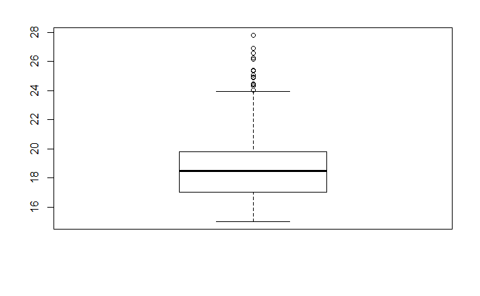

```r
boxplot(dataset$projections)
```

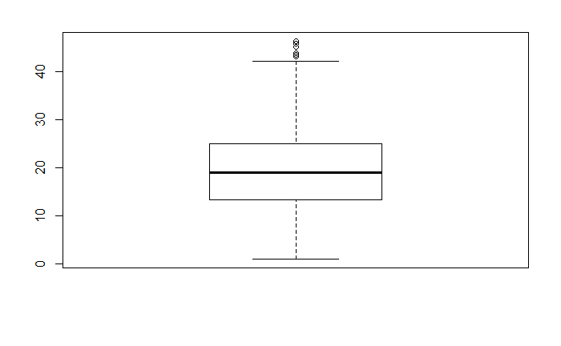

```r
boxplot(dataset$actuals)
```

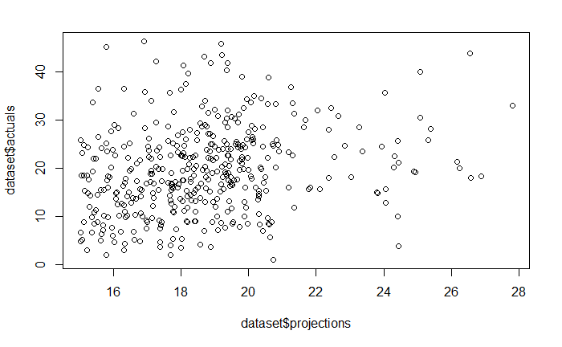

```r
plot(dataset$projections,dataset$actuals)
```

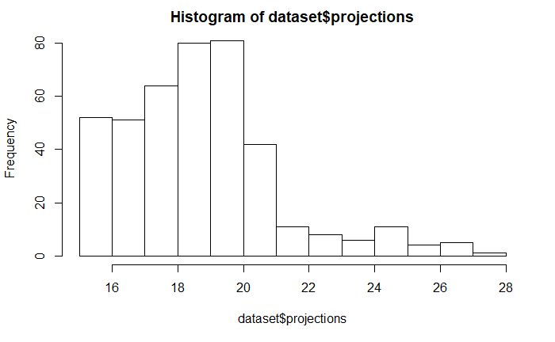

```r
hist(dataset$projections)
```

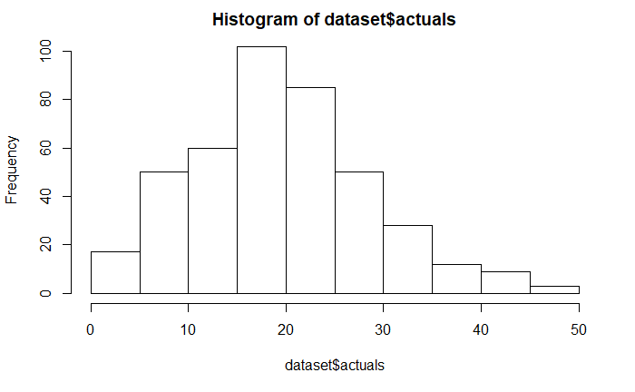

```r
hist(dataset$actuals)
```

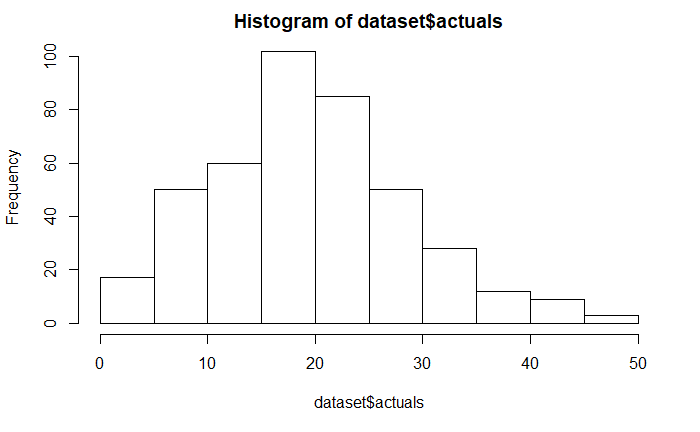

```r
hist(dataset$actuals,breaks=10)
```

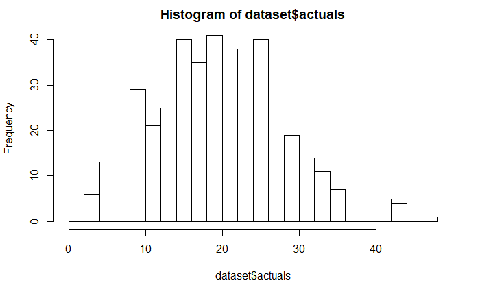

```r
hist(dataset$actuals,breaks=30)
```

# Problem_3

```r
library(ISwR)
View(cars)
```

## Problem_3.a

There are 50 observations in this dataset comprising two variables speed and distance.

## Problem_3.b

```r
copy_cars<- cars
```

## Problem_3.c

```r
time<-(copy_cars$dist)/(copy_cars$speed)
copy_cars ['time']<- time
print(copy_cars)
```

| speed | dist | time |
| --- | --- | --- |
| 4 | 2 | 0.5000000 |
| 4 | 10 | 2.5000000 |
| 7 | 4 | 0.5714286 |
| 7 | 22 | 3.1428571 |
| 8 | 16 | 2.0000000 |
| 9 | 10 | 1.1111111 |
| 10 | 18 | 1.8000000 |
| 10 | 26 | 2.6000000 |
| 10 | 34 | 3.4000000 |
| 11 | 17 | 1.5454545 |

[output cut: 40 more lines]

```r
NA
```

## Problem_3.d

```r
head(copy_cars,14)
```

|  | speed | dist | time |
| --- | --- | --- | --- |
| 1 | 4 | 2 | 0.5000000 |
| 2 | 4 | 10 | 2.5000000 |
| 3 | 7 | 4 | 0.5714286 |
| 4 | 7 | 22 | 3.1428571 |
| 5 | 8 | 16 | 2.0000000 |
| 6 | 9 | 10 | 1.1111111 |
| 7 | 10 | 18 | 1.8000000 |
| 8 | 10 | 26 | 2.6000000 |
| 9 | 10 | 34 | 3.4000000 |
| 10 | 11 | 17 | 1.5454545 |

[output cut: 4 more lines]

## Problem_3.e

```r
median(copy_cars$time)
```

```
[1] 2.522727
```

## Problem_3.f

```r
our.five.sum2<-fivenum(copy_cars$time)
summary(our.five.sum2)
```

```
   Min. 1st Qu.  Median    Mean 3rd Qu.    Max.
  0.500   1.895   2.523   2.766   3.200   5.714
```

```r
View(our.five.sum2)
Q1<-our.five.sum2[2]
Q3<-our.five.sum2[4]
print(Q1)
```

```
[1] 1.894737
```

```r
print(Q3)
```

```
[1] 3.2
```